# Lecture 9

# Set up

```r
using <- function(...) {
    libs <- unlist(list(...))
    need <- libs <- libs[!unlist(lapply(libs, require, character.only = T))]
    if(length(need) > 0){
        install.packages(need, repos = "https://cloud.r-project.org")
        need <- need[!unlist(lapply(need, require, character.only = T))]
        if (length(need) > 0) {
          if (!requireNamespace("BiocManager", quietly = T))
            install.packages("BiocManager")
          BiocManager::install(need)
        }
    }
    lapply(libs, require, character.only = T)
}
using("data.table", "tidyverse", "SummarizedExperiment", "pheatmap")
```

# Prepare data

As opposed to working from raw data, today we will be working with those pre-processed by TCGA

## Downloading from TCGA

Rather than retrieving the dataset piece-by-piece manually, we can access it more programmatically. Since it may take a while to download, you’ve been provided with the output of this chunk

You don’t need to run this chunk in class

```r
library(TCGAbiolinks)
library(FEM)
library(biomaRt)
samples <- data.frame(barcodes = c("TCGA-BB-A5HZ","TCGA-CN-4739","TCGA-CN-4727","TCGA-CV-5441",
                                   "TCGA-CV-6441","TCGA-P3-A6T6","TCGA-UF-A71D","TCGA-BA-A4IF",
                                   "TCGA-CR-5247","TCGA-BA-5555","TCGA-BB-4217","TCGA-CQ-5323",
                                   "TCGA-DQ-5624","TCGA-CN-4722","TCGA-P3-A5Q5","TCGA-CV-5430",
                                   "TCGA-BA-A4IG","TCGA-HD-7229","TCGA-CR-5243","TCGA-BA-4075"),
                      names = c("NSD1m_1","NSD1m_2","NSD1m_3","NSD1m_4","NSD1m_5","NSD1m_6",
                                "NSD1m_7","NSD1m_8","NSD1m_9","NSD1m_10","noNSD1m_1",
                                "noNSD1m_2","noNSD1m_3","noNSD1m_4","noNSD1m_5","noNSD1m_6",
                                "noNSD1m_7","noNSD1m_8","noNSD1m_9","noNSD1m_10"),
                      stringsAsFactors = F)

query.meth <- GDCquery(project = "TCGA-HNSC",
                       data.category = "DNA Methylation",
                       platform = "Illumina Human Methylation 450",
                       barcode = samples$barcodes)
GDCdownload(query.meth)
data.meth <- GDCprepare(query = query.meth, save = TRUE,
                        save.filename = "meth.RData")

query.exp <- GDCquery(project = "TCGA-HNSC",
                      data.category = "Transcriptome Profiling",
                      data.type = "Gene Expression Quantification",
                      workflow.type = "HTSeq - Counts",
                      barcode = samples$barcodes)
GDCdownload(query.exp)
data.exp <- GDCprepare(query = query.exp, save = TRUE,
                        save.filename = "exp.RData")

# Additional annotation
data("probe450kfemanno")
probes <- as.data.frame(simplify2array(probe450kfemanno))

# Ensembl Gene ID <-> Probe ID
ensembl <- useMart("ensembl",dataset="hsapiens_gene_ensembl")
tx <- unique(sub('\\..*$','',rowData(data.meth)$Transcript_ID))
map <- getBM(attributes = c('ensembl_transcript_id','ensembl_gene_id'),
             filters = 'ensembl_transcript_id', values = tx,
             mart = ensembl)
dict <- data.frame(probe = rownames(rowData(data.meth)),
                   transcript = sub('\\..*$','',rowData(data.meth)$Transcript_ID))
dict$gene <- plyr::mapvalues(dict$transcript, map$ensembl_transcript_id, map$ensembl_gene_id)
```

## Import

We can now load in the prepared data and make some further adjustments

```r
load('lec9.RData')

# Discard normal tissue samples
data.meth <- subset(data.meth, select = data.meth$shortLetterCode != "NT")

# Replace barcodes with readable names
colnames(data.meth) <- colnames(data.exp) <- samples$names

# Discard probes with all NA values
mat.meth <- assay(data.meth) %>%
  subset(rowSums(is.na(.)) != ncol(.))
```

# Distribution

## Genome-wide

One of the first things to check would be the distribution of methylation levels across the genome

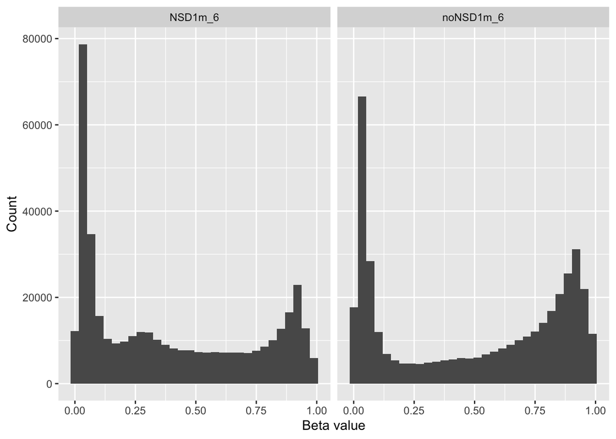

```r
# Reshape for plotting
data.plt <- melt(mat.meth, varnames = c("probe","sample")) %>%
  mutate(NSD1 = ifelse(grepl("noNSD1",sample), "+", "-"))

# Plot individual samples
ggplot(data.plt[data.plt$sample %in% c("NSD1m_6","noNSD1m_6"),], aes(x = value)) +
  geom_histogram() + labs (x = "Beta value", y = "Count") + facet_grid(. ~ sample)
```

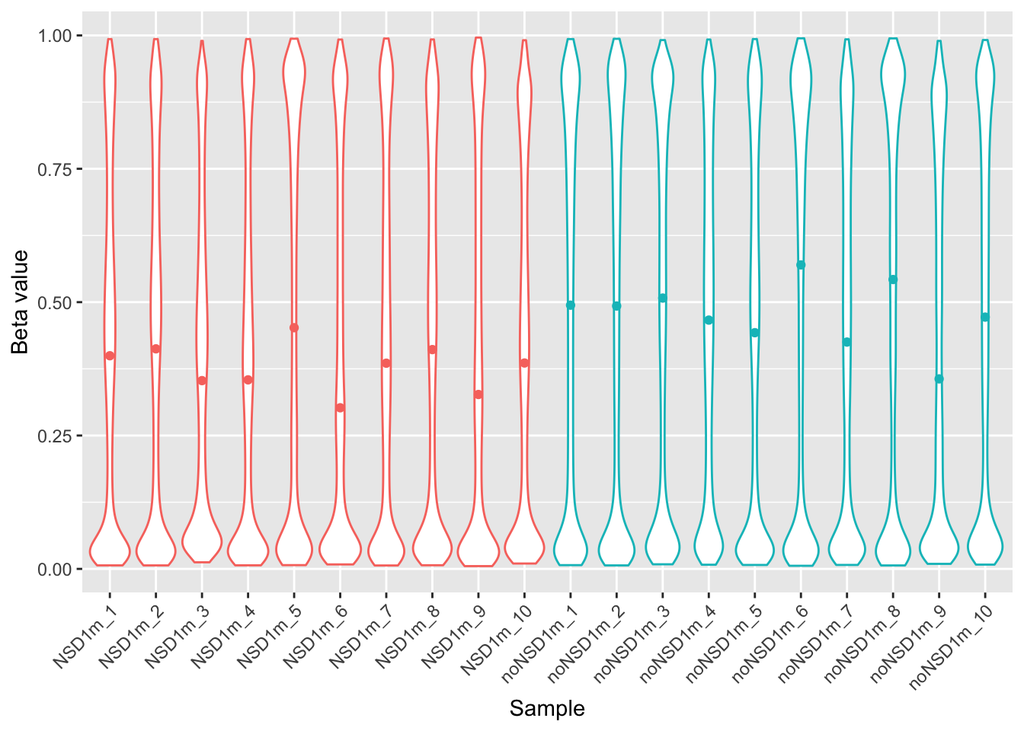

```r
# Plot all samples
ggplot(data.plt, aes(x = sample, y = value)) +
  geom_violin(aes(color = NSD1), show.legend = F) +
  stat_summary(aes(color = NSD1), fun.y = median, geom = "point", show.legend = F) +
  labs(x = "Sample", y = "Beta value") +
  theme(axis.text.x = element_text(angle = 45, vjust = 1, hjust = 1))
```

## Specific regions

```r
# Split probes based on feature type
ft <- split(as.character(rowData(data.meth)$Composite.Element.REF),
            f = rowData(data.meth)$Feature_Type)

# Split probes based on gene group
gg <- split(as.character(probes$probeID), f = probes$GeneGroup %>%
              as.numeric() %>%
              replace(., is.na(.), 7))
```

Feature_Type

| ID | Definition |
| --- | --- |
| N_Shore | 0-2kb upstream from CGI |
| S_Shore | 0-2kb downstream from CGI |
| N_Shelf | 2-4kb upstream from CGI |
| S_Shelf | 2-4kb downstream from CGI |

GeneGroup

| ID | Definition |
| --- | --- |
| 1 | TSS1500 |
| 2 | TSS200 |
| 3 | 5’ UTR |
| 4 | 1st exon |
| 5 | gene body |
| 6 | 3’ UTR |
| NA/7 | ambiguous |

Taking the gene body as an example

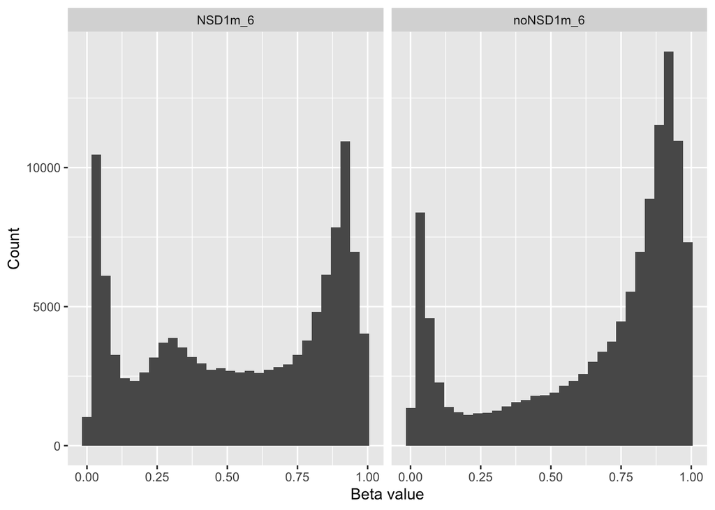

```r
# Pick a particular region
data.plt.reg <- data.plt[data.plt$probe %in% gg$`5`,]

# Individual samples
ggplot(data.plt.reg[data.plt.reg$sample %in% c("NSD1m_6","noNSD1m_6"),], aes(x = value)) +
  geom_histogram() + labs (x = "Beta value", y = "Count") + facet_grid(. ~ sample)
```

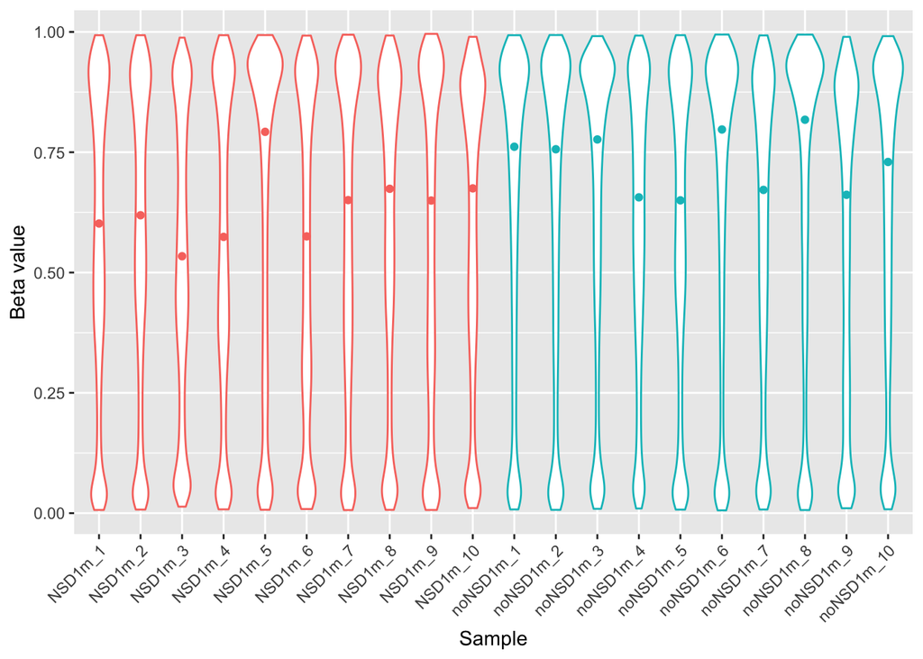

```r
# All samples
ggplot(data.plt.reg, aes(x = sample, y = value)) +
  geom_violin(aes(color = NSD1), show.legend = F) +
  stat_summary(aes(color = NSD1), fun.y = median, geom="point", show.legend = F) +
  labs(x = "Sample", y = "Beta value") +
  theme(axis.text.x = element_text(angle = 45, vjust = 1, hjust = 1))
```

1. Does any other subset of probes exhibit unique patterns>

# Clustering

Given the beta value matrix, we can adopt similar approaches as we’ve used for RNA-seq expression matrices

## Methylation-based

For example, both hierarchical clustering and PCA can be directly applied

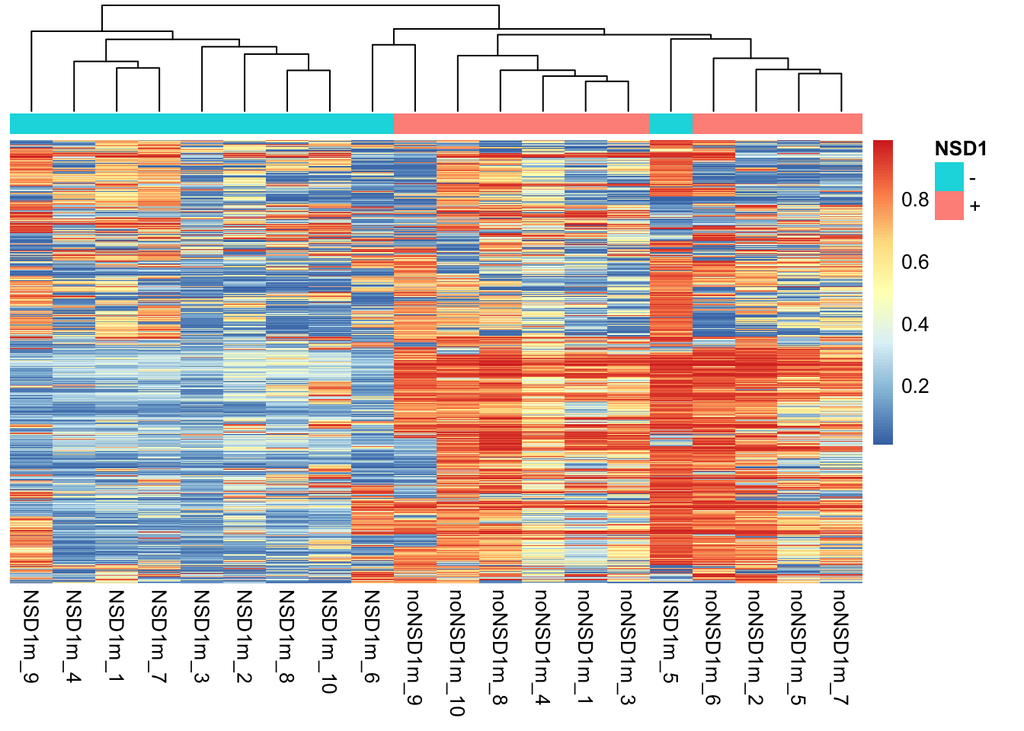

```r
# HCA on the n most variable probes
sds <- apply(mat.meth, 1, sd)
keep <- order(sds, decreasing = T)[1:1000]
anno.col <- data.frame(NSD1=rep(c("-","+"),each=10))
rownames(anno.col) <- colnames(mat.meth)
pheatmap(
  as.matrix(mat.meth[keep,]),
  treeheight_row = 0,
  show_rownames = F,
  annotation_col = anno.col,
  annotation_names_col = F,
  clustering_distance_cols = "correlation",
  clustering_distance_rows = "correlation"
)
```

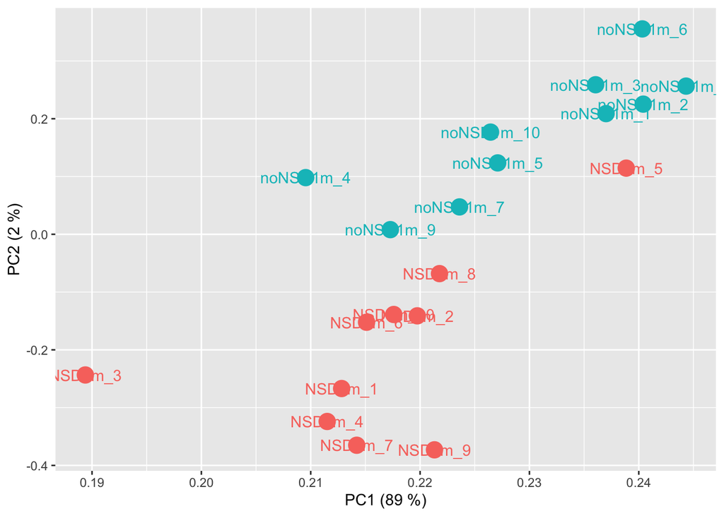

```r
# PCA
res.pca <- prcomp(na.omit(mat.meth))
comps <- summary(res.pca)$importance[2,1:2] * 100
res.pca$rotation %>%
  data.frame %>%
  mutate(samples = rownames(.)) %>%
  mutate(condition = ifelse(grepl("noNSD1",samples),"+","-")) %>%
  ggplot(aes(x = PC1, y = PC2, color = condition)) +
    geom_point(size = 5, show.legend = F) +
    geom_text(aes(label = samples), show.legend = F) +
    xlab(sprintf("PC1 (%d %%)",round(comps[1]))) +
    ylab(sprintf("PC2 (%d %%)",round(comps[2])))
```

## Expression-based

```r
mat.exp <- log2(assay(data.exp) + 1)
```

2. Perform HCA & PCA on the gene expression matrix and compare with the results based on DNA methylation

# Interrelation

Now we proceed and investigate the relationship between expression and methylation

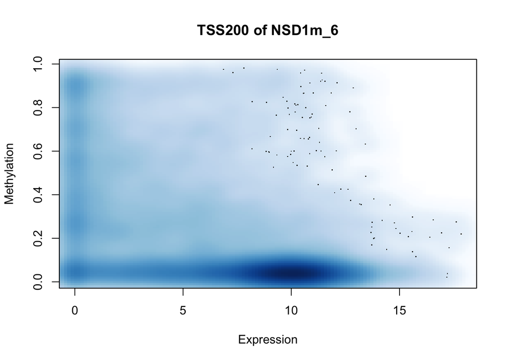

```r
# Only focus on genes and probes with valid mapping
mat.meth.ok <- mat.meth[rownames(mat.meth) %in% dict$probe,]
mat.exp.ok <- mat.exp[rownames(mat.exp) %in% dict$gene,]

# Look at a particular type of CpG sites
reg <- gg$`2`
reg.name <- "TSS200"

# Merge methylation with expression data
dat.reg <- melt(mat.meth.ok[rownames(mat.meth.ok) %in% reg,],
                 varnames = c("probe","samples"), value.name = "beta") %>%
  left_join(., dict, by = "probe") %>%
  left_join(., melt(mat.exp.ok,varnames=c("gene","samples")),
            by = c("gene","samples"))

# Get mean methylation level of all probes associated with each gene
samp <- "NSD1m_6"
dat.plt <- dat.reg[dat.reg$samples == samp,] %>%
  group_by(gene) %>%
  summarise(beta = mean(beta), expr = mean(value))
smoothScatter(x = dat.plt$expr, y = dat.plt$beta, xlab = "Expression",
              ylab = "Methylation", main = paste0(reg.name," of ",samp))
```

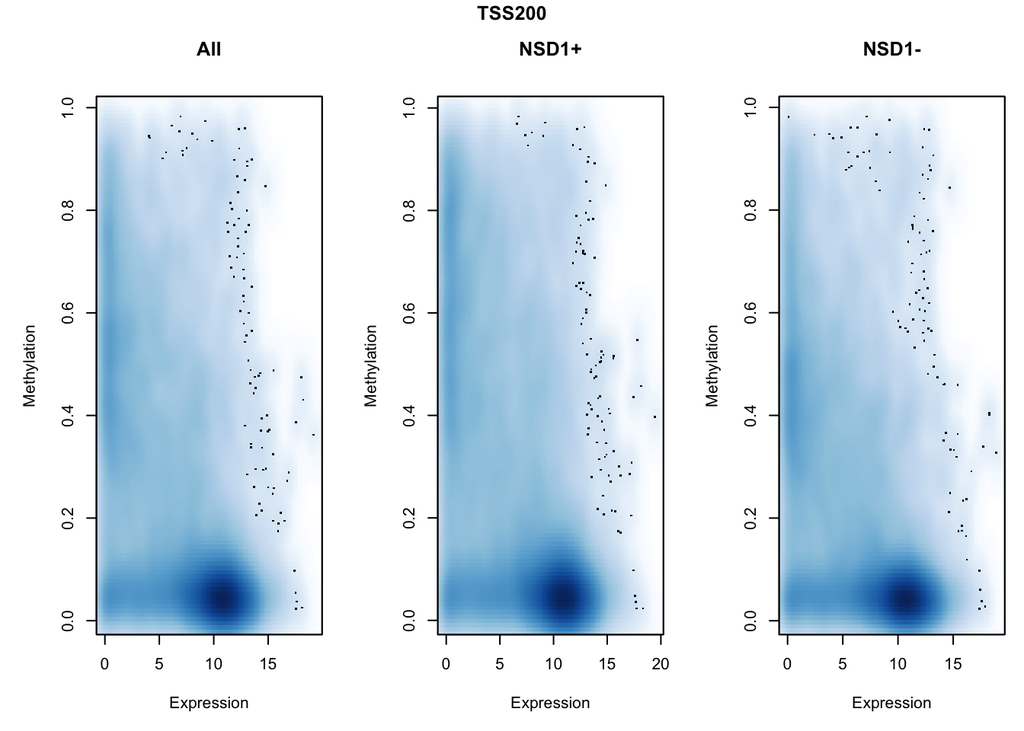

```r
# Aggregate samples within conditions by taking the mean
dat.wt <- dat.reg[grepl("noNSD1",dat.reg$samples),] %>%
  group_by(gene) %>%
  summarise(beta = mean(beta), expr = mean(value))
dat.mt <- dat.reg[!grepl("noNSD1",dat.reg$samples),] %>%
  group_by(gene) %>%
  summarise(beta = mean(beta), expr = mean(value))
dat.all <- dat.reg %>%
  group_by(gene) %>%
  summarise(beta = mean(beta), expr = mean(value))

par(mfrow=c(1,3),mar=c(5,5,5,1))
smoothScatter(x = dat.all$expr, y = dat.all$beta, xlab = "Expression", ylab = "Methylation", main = "All")
smoothScatter(x = dat.wt$expr, y = dat.wt$beta, xlab = "Expression", ylab = "Methylation", main = "NSD1+")
smoothScatter(x = dat.mt$expr, y = dat.mt$beta, xlab = "Expression", ylab = "Methylation", main = "NSD1-")
title(reg.name, line = -1, outer = TRUE)
```

3. Do you see similar patterns within gene bodies?